# WeRateDogs Twitter Data: Analyses Report

## WeRateDogs Data :

#### The WeRateDogs Enhanced Twitter archive contains data extracted from 2356 of the 5000+ tweets from the @dog_rates twitter account, posted between

#### November 15, 2015 and August 1, 217. This data is comprised of dog ratings that were taken from the text of the tweet along with the dog name and dog stage if present.

#### The retweet count and favourite count for each tweet were not included in the enhanced archive, and so I had to download this additional data from the twitter account using the tweet ID from the archive.

#### Along with the Twitter data, I also downloaded an image predictions ﬁle from Udacity servers containing the top 3 predictions for dog breeds based on the images from the tweets (there can be up to 4).

### Wrangling Data :

#### Before I could begin the analysis, the data had to be wrangled into shape to make it easier. I assessed the data both visually and programmatically for quality and tidiness; the quality of data is determined mainly by looking at several aspects or dimensions to ensure that it is complete, valid, accurate and consistent. After cleaning many of the issues found during the assessment, there were about 1950 tweets with good quality data.

### Insights :

- Favourite Counts Are Higher Than Retweet Counts
- Strong Relationship Between Favourite Count And Retweet Count
- correlation chart is useful for finding connections between variables
- Word Cloud with Tweets
- Data partition on basis of Life stage of dogs
- Correlation with rating

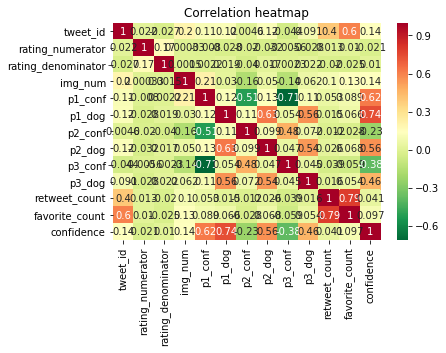

```python
# correlation heatmap
corr = full_twitter_data.corr()
plt.title('Correlation heatmap')
sns.heatmap(corr,
            xticklabels=corr.columns.values,
            yticklabels=corr.columns.values,
           annot = True,
           cmap='RdYlGn_r');
```

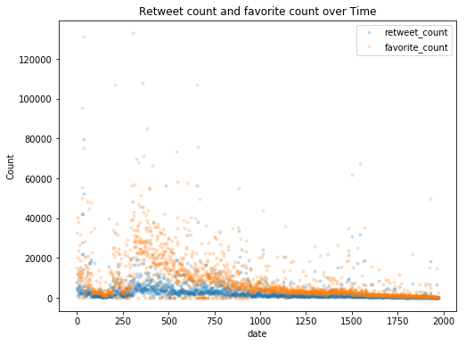

```python
full_twitter_data.plot.line(y =['retweet_count', 'favorite_count'], style = '.', alpha = .2, figsize=(8,6))

plt.title('Retweet count and favorite count over Time')
plt.xlabel('date')
plt.ylabel('Count');
```

```
(-1.288684701931456,
 1.2387919546777029,
 -1.2205837462231326,
 1.2100327936419484)
```

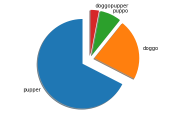

```python
life_stage_count = list(full_twitter_data[full_twitter_data['life_stage'] != 'None']['life_stage'].value_counts())[0:4]
life_stages = full_twitter_data[full_twitter_data['life_stage'] != 'None']['life_stage'].value_counts().index.tolist()[0:4]
explode = (0.2, 0.1, 0.1, 0.1)

figure1, axis1 = plt.subplots()
axis1.pie(life_stage_count, explode = explode, labels = life_stages, shadow = True, startangle = 90)
axis1.axis('equal')
```

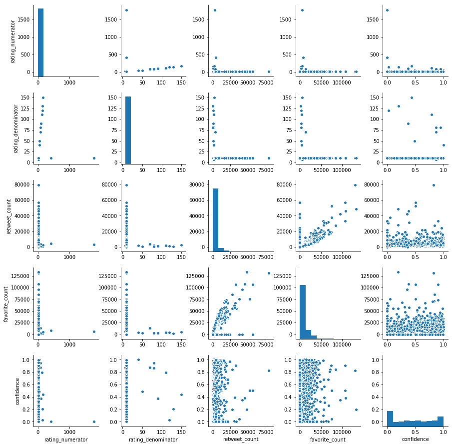

```python
sns.pairplot(full_twitter_data, vars=["rating_numerator", "rating_denominator", "retweet_count", "favorite_count", "confidence"]);
```

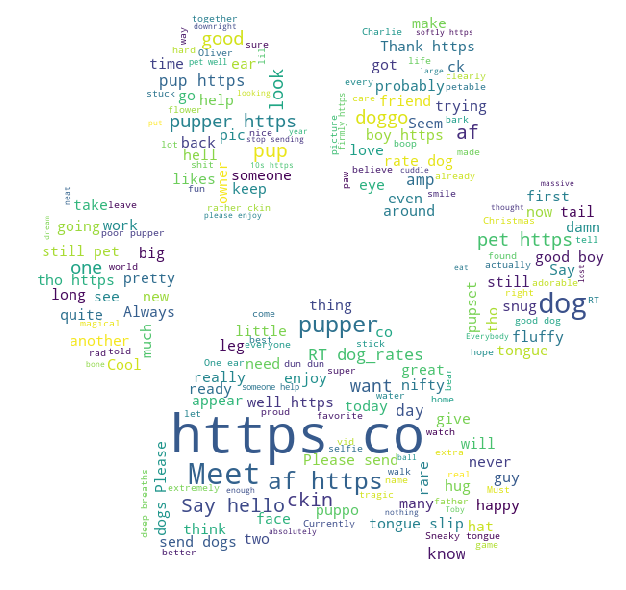

```python
gen_wc(text, mask)
```